# Frequency Analysis - OSHA Severe Reports

Abdullah Alsharef

3/14/2020

# Introduction

This Document shows the frequency of the followings:

- State
- Contractor (Industry)
- Hospitalized
- Amputation
- Event
- Source (Main Source)
- Main Source and Secondary source
- Part of Body
- Nature
- Part of Body and nature

The database was obtianed from *[OSHA Severe Reports Database](https://www.osha.gov/severeinjury/)*. The Contractor industry cased were obtained from *[North American Industry Classification System](https://www.census.gov/eos/www/naics/downloadables/downloadables.html)*. Event, Source, Part of Body, Nature were cross referenced from the *[The Occupational Injury and Illness Classification System (OIICS) Manual](https://www.bls.gov/iif/oshoiics.htm)*.

The database was downloaded on 2/23/2020. The database has number of severe injury across different industries.

# Compare Construction with different Industries

This analysis investigates the proportion of construction, compared with other industires.

- The total number of injury reports = 48036 reports (from all indusries)
- NUmber of reports with missing industries = 2 reports
- The relative proportion is for cases after discarding the two missing cases - n = 48034

```r
# read all cases
all <- read_excel("datasets/rmarkdown files/severeinjury_ORIGINAL__modified_E.xlsx")

# read the naics
naics <- read_excel("datasets/rmarkdown files/naics/NAICS_L2.xlsx",sheet = 1, col_types = c( "numeric","guess"))

# left join
all_v2 <- left_join(all,naics)
# number of cases (blank)
sum_all_v2 <- all_v2 %>%
  filter(!is.na(NAICS_L2_v1)) %>%
  count(NAICS_L2_v1, sort = T)

# Proportion
sum_all_v2 %>%
  rename(Industry =  NAICS_L2_v1) %>%
  mutate(Percentage = n*100 / sum(n))
```

| Industry | n | Percentage |
| --- | --- | --- |
| Manufacturing | 15949 | 33.20356414 |
| Construction | 8563 | 17.82695591 |
| Transportation and Warehousing | 4133 | 8.60432194 |
| Retail Trade | 3472 | 7.22821335 |
| Administrative and Support and Waste Management and Remediation Services | 2645 | 5.50651622 |
| Wholesale Trade | 2636 | 5.48777949 |
| Health Care and Social Assistance | 2261 | 4.70708248 |
| Mining, Quarrying, and Oil and Gas Extraction | 1585 | 3.29974601 |
| Accommodation and Food Services | 974 | 2.02773036 |
| Agriculture, Forestry, Fishing and Hunting | 876 | 1.82370821 |

[output cut: 11 more lines]

Intresteingly, construction is second in terms of severe injuries followed by manufacturing.

- Major finding: although fatalities statistics shows a decrease of improvement in the number of fatalities, the construction industry is second in severe injuries followed by Manfufacturing.
- Check and compare the rank of fatalities between construction and other industires.

# Analysis by Time

- Would there be a way to perform time series forecasting for the monthly number of cases.
  - One model to consider is seasonality.

```r
# read Construction cases

cons <- read_excel("datasets/rmarkdown files/Osha_construction_Data_3-14-2020_neededVariables.xlsx")

# extract month and year
cons_v2 <-cons %>%
  mutate(EventDate_Month = month(EventDate),
         EventDate_year = year(EventDate) )
# count
freq_cons_v2 <- cons_v2 %>%
  count(EventDate_Month,EventDate_year) %>%
  arrange(EventDate_year, EventDate_Month)

freq_cons_v2 %>%
  rename (Month = EventDate_Month,Year = EventDate_year)
```

| Month | Year | n |
| --- | --- | --- |
| 1 | 2015 | 129 |
| 2 | 2015 | 105 |
| 3 | 2015 | 152 |
| 4 | 2015 | 145 |
| 5 | 2015 | 129 |
| 6 | 2015 | 153 |
| 7 | 2015 | 192 |
| 8 | 2015 | 150 |
| 9 | 2015 | 178 |
| 10 | 2015 | 147 |

[output cut: 45 more lines]

```r
freq_cons_v3 <- freq_cons_v2 %>%
  mutate(dat = paste0(EventDate_Month, sep = "/" , EventDate_year)) %>%
  mutate (dat2 = date(parse_date_time(dat, "my"))  )
```

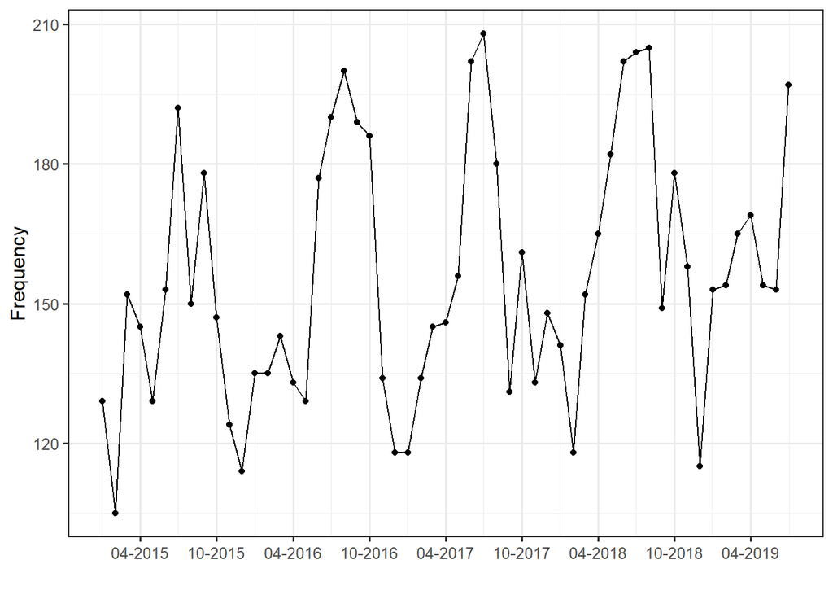

```r
# time series plot
p <- ggplot(freq_cons_v3, aes(x=dat2, y=n)) +
  geom_line() +
  geom_point() +
  xlab("") +
  ylab("Frequency")+
  scale_x_date(date_breaks = "6 month", date_labels = "%m-%Y") +
    theme_bw(12)
p
```

```r
#  scale_x_date(date_breaks = "1 month", date_labels = "%m-%Y")
```

```r
# sum by year
freq_cons_v3 %>%
  group_by(EventDate_year) %>%
  summarise(sum1 = sum(n)) %>%
  filter(EventDate_year < 2019) %>%
  rename(Year = EventDate_year, Frequency = sum1)
```

| Year | Frequency |
| --- | --- |
| 2015 | 1718 |
| 2016 | 1869 |
| 2017 | 1862 |
| 2018 | 1969 |

- The first construction case was reported on 1/2/2015
- The last construction case was reported on 7/31/2019

# Analysis by State

- Number of cases = 8563
- No missing

```r
proper=function(s) sub("(.)", ("\\U\\1"), tolower(s), pe=TRUE)

# Viz the freq by State
state <- cons_v2 %>%
  count(State, sort = T) %>%
  mutate(State = proper(State))

state
```

| State | n |
| --- | --- |
| Texas | 1688 |
| Florida | 1430 |
| Pennsylvania | 561 |
| New york | 524 |
| Ohio | 484 |
| Colorado | 401 |
| Georgia | 384 |
| Illinois | 351 |
| Wisconsin | 247 |
| Louisiana | 225 |

[output cut: 41 more lines]

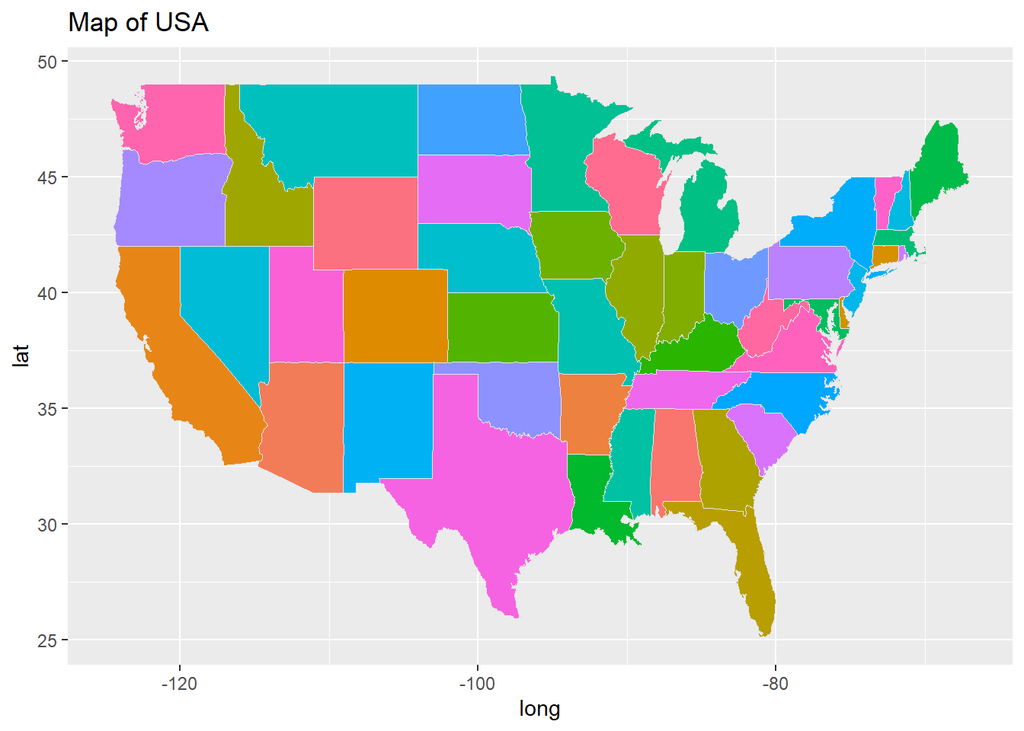

```r
# data viz
thismap <- map_data ("state")
ggplot(thismap, aes(long, lat, group=group, fill=region)) +
  geom_polygon(show.legend = F) +
  geom_polygon(color = "gray90", size = 0.1) + guides(fill = FALSE) +
  ggtitle("Map of USA")
```

```r
# consider adding ggtext to include the islelands

# review
# https://socviz.co/maps.html
# https://www.datanovia.com/en/blog/how-to-create-a-map-using-ggplot2/
# https://stackoverflow.com/questions/23714052/ggplot-mapping-us-counties-problems-with-visualization-shapes-in-r
# https://stackoverflow.com/questions/48832201/plot-a-numerical-values-in-united-states-map-based-on-abbreviated-state-names
# https://stackoverflow.com/questions/48832201/plot-a-numerical-values-in-united-states-map-based-on-abbreviated-state-names
```

str(thismap)

# Analysis By Contractor

## Contractor - Level 1

```r
cons_v2 %>%
  count(NAICS_L3, sort = T)
```

| NAICS_L3 | n |
| --- | --- |
| Specialty Trade Contractors | 5093 |
| Heavy and Civil Engineering Construction | 1838 |
| Construction of Buildings | 1630 |
| Construction | 2 |

## Contractor - Level 2

```r
cons_v2 %>%
  count(NAICS_L4, sort = T)
```

| NAICS_L4 | n |
| --- | --- |
| Foundation, Structure, and Building Exterior Contractors | 2105 |
| Building Equipment Contractors | 1625 |
| Nonresidential Building Construction | 1266 |
| Utility System Construction | 878 |
| Other Specialty Trade Contractors | 751 |
| Highway, Street, and Bridge Construction | 703 |
| Building Finishing Contractors | 611 |
| Residential Building Construction | 364 |
| Other Heavy and Civil Engineering Construction | 241 |
| Land Subdivision | 16 |

[output cut: 2 more lines]

## Contractor - Level 3

```r
cons_v2 %>%
  count(NAICS_L5, sort = T)
```

| NAICS_L5 | n |
| --- | --- |
| Commercial and Institutional Building Construction | 915 |
| Electrical Contractors and Other Wiring Installation Contractors | 841 |
| Highway, Street, and Bridge Construction | 703 |
| Roofing Contractors | 693 |
| Plumbing, Heating, and Air-Conditioning Contractors | 633 |
| All Other Specialty Trade Contractors | 403 |
| Structural Steel and Precast Concrete Contractors | 388 |
| Residential Building Construction | 364 |
| Poured Concrete Foundation and Structure Contractors | 359 |
| Industrial Building Construction | 350 |

[output cut: 22 more lines]

- We will use level 1 and/or level 2 as level 3 increase the dimensions.

# Analysis By Event

## Event - Level 1

```r
cons_v2 %>%
  count(event_L1, sort = T)
```

| event_L1 | n |
| --- | --- |
| FALLS, SLIPS, TRIPS | 3422 |
| CONTACT WITH OBJECTS AND EQUIPMENT | 3388 |
| EXPOSURE TO HARMFUL SUBSTANCES OR ENVIRONMENTS | 851 |
| TRANSPORTATION INCIDENTS | 546 |
| FIRES AND EXPLOSIONS | 138 |
| Nonclassifiable | 91 |
| OVEREXERTION AND BODILY REACTION | 75 |
| VIOLENCE AND OTHER INJURIES BY PERSONS OR ANIMALS | 52 |

## Event - Level 2

```r
cons_v2 %>%
  count(event_L2, sort = T)
```

| event_L2 | n |
| --- | --- |
| Falls to lower level | 2943 |
| Struck by object or equipment | 1985 |
| Caught in or compressed by equipment or objects | 1019 |
| Exposure to electricity | 394 |
| Exposure to temperature extremes | 376 |
| Falls on same level | 325 |
| Pedestrian vehicular incidents | 315 |
| Struck against object or equipment | 204 |
| Nonroadway incidents involving motorized land vehicles | 177 |
| Fires | 101 |

[output cut: 27 more lines]

## Event - Level 3

```r
cons_v2 %>%
  count(event_L3, sort = T)
```

| event_L3 | n |
| --- | --- |
| Other fall to lower level | 2403 |
| Struck by falling object or equipment—other than powered vehicle | 746 |
| Compressed or pinched by shifting objects or equipment | 535 |
| Injured by handheld object or equipment | 426 |
| Fall through surface or existing opening | 359 |
| Caught in running equipment or machinery | 347 |
| Struck by discharged or flying object | 321 |
| Direct exposure to electricity | 313 |
| Exposure to environmental heat | 287 |
| Struck by powered vehicle—nontransport | 197 |

[output cut: 102 more lines]

## Event 1 and 2

```r
tabyl_1 <- cons_v2 %>%
  tabyl ( event_L2, event_L1)

write.csv(tabyl_1, "datasets/rmarkdown files/output/tabyl_1.csv", na = "")
```

- We will use level 1 and/or level 2 as level 3 increase the dimensions.

# Hospitilization

```r
cons_v2 %>%
  count(Hospitalized_Y_N, sort = T)
```

| Hospitalized_Y_N | n |
| --- | --- |
| Y | 7652 |
| N | 911 |

## Hospitilization by Event

```r
# cluster the anlysis by Event
cons_v2 %>%
  group_by(event_L1) %>%
  count(Hospitalized_Y_N)
```

| event_L1 | Hospitalized_Y_N | n |
| --- | --- | --- |
| CONTACT WITH OBJECTS AND EQUIPMENT | N | 860 |
| CONTACT WITH OBJECTS AND EQUIPMENT | Y | 2528 |
| EXPOSURE TO HARMFUL SUBSTANCES OR ENVIRONMENTS | Y | 851 |
| FALLS, SLIPS, TRIPS | N | 24 |
| FALLS, SLIPS, TRIPS | Y | 3398 |
| FIRES AND EXPLOSIONS | Y | 138 |
| Nonclassifiable | N | 7 |
| Nonclassifiable | Y | 84 |
| OVEREXERTION AND BODILY REACTION | Y | 75 |
| TRANSPORTATION INCIDENTS | N | 20 |

[output cut: 2 more lines]

```r
# cluster the anlysis by Event
cons_v2 %>%
  tabyl (event_L1, Hospitalized_Y_N)
```

| event_L1 | N | Y |
| --- | --- | --- |
| CONTACT WITH OBJECTS AND EQUIPMENT | 860 | 2528 |
| EXPOSURE TO HARMFUL SUBSTANCES OR ENVIRONMENTS | 0 | 851 |
| FALLS, SLIPS, TRIPS | 24 | 3398 |
| FIRES AND EXPLOSIONS | 0 | 138 |
| Nonclassifiable | 7 | 84 |
| OVEREXERTION AND BODILY REACTION | 0 | 75 |
| TRANSPORTATION INCIDENTS | 20 | 526 |
| VIOLENCE AND OTHER INJURIES BY PERSONS OR ANIMALS | 0 | 52 |

# Amputation

```r
cons_v2 %>%
  count(Amputation_Y_N)
```

| Amputation_Y_N | n |
| --- | --- |
| N | 7265 |
| Y | 1298 |

## Amputation by Event

```r
# cluster the anlysis by Event
cons_v2 %>%
  tabyl (event_L1, Amputation_Y_N)
```

| event_L1 | N | Y |
| --- | --- | --- |
| CONTACT WITH OBJECTS AND EQUIPMENT | 2179 | 1209 |
| EXPOSURE TO HARMFUL SUBSTANCES OR ENVIRONMENTS | 846 | 5 |
| FALLS, SLIPS, TRIPS | 3395 | 27 |
| FIRES AND EXPLOSIONS | 137 | 1 |
| Nonclassifiable | 75 | 16 |
| OVEREXERTION AND BODILY REACTION | 75 | 0 |
| TRANSPORTATION INCIDENTS | 506 | 40 |
| VIOLENCE AND OTHER INJURIES BY PERSONS OR ANIMALS | 52 | 0 |

## Amputation by Source - Level 1

```r
cons_v2 %>%
  tabyl (source1_L1, Amputation_Y_N)
```

| source1_L1 | N | Y |
| --- | --- | --- |
| CHEMICALS AND CHEMICAL PRODUCTS | 174 | 2 |
| CONTAINERS, FURNITURE AND FIXTURES | 152 | 52 |
| MACHINERY | 752 | 472 |
| Nonclassifiable | 366 | 54 |
| OTHER SOURCES | 455 | 7 |
| PARTS AND MATERIALS | 1177 | 339 |
| PERSONS, PLANTS, ANIMALS, AND MINERALS | 156 | 3 |
| STRUCTURES AND SURFACES | 2106 | 93 |
| TOOLS, INSTRUMENTS, AND EQUIPMENT | 1299 | 180 |
| VEHICLES | 628 | 96 |

## Amputation by Source - Level 2

```r
cons_v2 %>%
  tabyl (source1_L2, Amputation_Y_N) %>%
  arrange(desc(Y))
```

| source1_L2 | N | Y |
| --- | --- | --- |
| Metal, woodworking, and special material machinery | 75 | 191 |
| Building materials—solid elements | 473 | 164 |
| Handtools—powered | 227 | 140 |
| Construction, logging, and mining machinery | 331 | 108 |
| Material and personnel handling machinery | 283 | 95 |
| Nonclassifiable | 366 | 54 |
| Other structural elements | 880 | 54 |
| Highway vehicles, motorized | 402 | 52 |
| Machine, tool, and electric parts | 381 | 52 |
| Fasteners, connectors, ropes, ties | 138 | 49 |

[output cut: 56 more lines]

## Amputation by Part of Body - Level 1

```r
cons_v2 %>%
  tabyl (part_L1, Amputation_Y_N) %>%
  arrange(desc(Y))
```

| part_L1 | N | Y |
| --- | --- | --- |
| UPPER EXTREMITIES | 1273 | 1219 |
| LOWER EXTREMITIES | 1693 | 68 |
| Nonclassifiable | 658 | 8 |
| MULTIPLE BODY PARTS | 1142 | 3 |
| BODY SYSTEMS | 479 | 0 |
| HEAD | 746 | 0 |
| NECK, INCLUDING THROAT | 55 | 0 |
| TRUNK | 1219 | 0 |

## Amputation by Part of Body - Level 2

```r
cons_v2 %>%
  tabyl (part_L2, Amputation_Y_N) %>%
  arrange(desc(Y))
```

| part_L2 | N | Y |
| --- | --- | --- |
| Hand(s) | 599 | 1209 |
| Foot (feet) | 235 | 41 |
| Leg(s) | 1081 | 26 |
| Arm(s) | 355 | 8 |
| Nonclassifiable | 658 | 8 |
| Other multiple body parts | 773 | 2 |
| Lower extremities, unspecified | 17 | 1 |
| Multiple upper extremities locations | 100 | 1 |
| Upper and lower limb(s) | 115 | 1 |
| Upper extremities, unspecified | 4 | 1 |

[output cut: 24 more lines]

# Analysis By Source (Main Source)

## Source (Main Source) - Level 1

```r
cons_v2 %>%
  count(source1_L1, sort = T)
```

| source1_L1 | n |
| --- | --- |
| STRUCTURES AND SURFACES | 2199 |
| PARTS AND MATERIALS | 1516 |
| TOOLS, INSTRUMENTS, AND EQUIPMENT | 1479 |
| MACHINERY | 1224 |
| VEHICLES | 724 |
| OTHER SOURCES | 462 |
| Nonclassifiable | 420 |
| CONTAINERS, FURNITURE AND FIXTURES | 204 |
| CHEMICALS AND CHEMICAL PRODUCTS | 176 |
| PERSONS, PLANTS, ANIMALS, AND MINERALS | 159 |

## Source (Main Source) - Level 2

```r
cons_v2 %>%
  count(source1_L2, sort = T)
```

| source1_L2 | n |
| --- | --- |
| Ladders | 971 |
| Other structural elements | 934 |
| Building materials—solid elements | 637 |
| Structures other than buildings | 610 |
| Floors, walkways, ground surfaces | 515 |
| Highway vehicles, motorized | 454 |
| Construction, logging, and mining machinery | 439 |
| Machine, tool, and electric parts | 433 |
| Nonclassifiable | 420 |
| Material and personnel handling machinery | 378 |

[output cut: 56 more lines]

## Source (Main Source) - Level 3

```r
cons_v2 %>%
  count(source1_L3, sort = T)
```

| source1_L3 | n |
| --- | --- |
| Ladders—movable | 639 |
| Roofs | 547 |
| Scaffolds, staging | 424 |
| Nonclassifiable | 420 |
| Electric parts | 347 |
| Temperature extremes—environmental | 288 |
| Trucks—motorized freight hauling and utility | 279 |
| Structural metal materials | 269 |
| Ladders, unspecified | 262 |
| Cutting handtools—powered | 242 |

[output cut: 237 more lines]

## Source by Event - Level 1

```r
cons_v2 %>%
  tabyl (source1_L1, event_L1)
```

| source1_L1 | CONTACT WITH OBJECTS AND EQUIPMENT | EXPOSURE TO HARMFUL SUBSTANCES OR ENVIRONMENTS | FALLS, SLIPS, TRIPS | FIRES AND EXPLOSIONS | Nonclassifiable | OVEREXERTION AND BODILY REACTION | TRANSPORTATION INCIDENTS | VIOLENCE AND OTHER INJURIES BY PERSONS OR ANIMALS |
| --- | --- | --- | --- | --- | --- | --- | --- | --- |
| CHEMICALS AND CHEMICAL PRODUCTS | 24 | 96 | 0 | 56 | 0 | 0 | 0 | 0 |
| CONTAINERS, FURNITURE AND FIXTURES | 144 | 7 | 33 | 15 | 0 | 5 | 0 | 0 |
| MACHINERY | 830 | 24 | 160 | 9 | 6 | 5 | 190 | 0 |
| Nonclassifiable | 114 | 28 | 178 | 19 | 74 | 4 | 3 | 0 |
| OTHER SOURCES | 118 | 321 | 0 | 21 | 1 | 1 | 0 | 0 |
| PARTS AND MATERIALS | 1112 | 332 | 51 | 4 | 1 | 16 | 0 | 0 |
| PERSONS, PLANTS, ANIMALS, AND MINERALS | 43 | 4 | 30 | 0 | 0 | 30 | 0 | 52 |
| STRUCTURES AND SURFACES | 333 | 9 | 1848 | 3 | 2 | 4 | 0 | 0 |
| TOOLS, INSTRUMENTS, AND EQUIPMENT | 467 | 21 | 978 | 4 | 0 | 9 | 0 | 0 |
| VEHICLES | 203 | 9 | 144 | 7 | 7 | 1 | 353 | 0 |

```r
cons_v2 %>%
  count(event_L1, source1_L1, sort = T)
```

| event_L1 | source1_L1 | n |
| --- | --- | --- |
| FALLS, SLIPS, TRIPS | STRUCTURES AND SURFACES | 1848 |
| CONTACT WITH OBJECTS AND EQUIPMENT | PARTS AND MATERIALS | 1112 |
| FALLS, SLIPS, TRIPS | TOOLS, INSTRUMENTS, AND EQUIPMENT | 978 |
| CONTACT WITH OBJECTS AND EQUIPMENT | MACHINERY | 830 |
| CONTACT WITH OBJECTS AND EQUIPMENT | TOOLS, INSTRUMENTS, AND EQUIPMENT | 467 |
| TRANSPORTATION INCIDENTS | VEHICLES | 353 |
| CONTACT WITH OBJECTS AND EQUIPMENT | STRUCTURES AND SURFACES | 333 |
| EXPOSURE TO HARMFUL SUBSTANCES OR ENVIRONMENTS | PARTS AND MATERIALS | 332 |
| EXPOSURE TO HARMFUL SUBSTANCES OR ENVIRONMENTS | OTHER SOURCES | 321 |
| CONTACT WITH OBJECTS AND EQUIPMENT | VEHICLES | 203 |

[output cut: 46 more lines]

- We will use level 1 and/or level 2 after selecting the top 10 or 20 (still to be decided).

# Analysis By Main Source and Secondary Source

The number of cases with both main source and secondary source are 2792. The number of missing secondary source is 5771. The number of construction related cases is 8563.

## Main Source and Secondary source - Level 1

```r
# count the missing cases
miss_source2 <- cons_v2 %>%
  filter(is.na(source2_L1)) %>%
  count(source2_L1)

cons_v2 %>%
  filter(!is.na(source2_L1)) %>%
  count(source1_L1, source2_L1, sort = T)
```

| source1_L1 | source2_L1 | n |
| --- | --- | --- |
| STRUCTURES AND SURFACES | STRUCTURES AND SURFACES | 363 |
| TOOLS, INSTRUMENTS, AND EQUIPMENT | STRUCTURES AND SURFACES | 209 |
| PARTS AND MATERIALS | MACHINERY | 162 |
| STRUCTURES AND SURFACES | PARTS AND MATERIALS | 132 |
| STRUCTURES AND SURFACES | OTHER SOURCES | 118 |
| PARTS AND MATERIALS | PARTS AND MATERIALS | 113 |
| PARTS AND MATERIALS | TOOLS, INSTRUMENTS, AND EQUIPMENT | 97 |
| TOOLS, INSTRUMENTS, AND EQUIPMENT | PARTS AND MATERIALS | 94 |
| PARTS AND MATERIALS | VEHICLES | 92 |
| MACHINERY | STRUCTURES AND SURFACES | 88 |

[output cut: 82 more lines]

## Main Source and Secondary source - Level 2

```r
# show top 20 - the number of combination is 591
cons_v2 %>%
  filter(!is.na(source2_L1)) %>%
  count(source1_L2, source2_L2, sort = T) %>%
  top_n(20)
```

| source1_L2 | source2_L2 | n |
| --- | --- | --- |
| Ladders | Floors, walkways, ground surfaces | 185 |
| Other structural elements | Floors, walkways, ground surfaces | 153 |
| Structures other than buildings | Floors, walkways, ground surfaces | 101 |
| Fasteners, connectors, ropes, ties | Handtools—powered | 54 |
| Floors, walkways, ground surfaces | Environmental and elemental conditions | 45 |
| Building materials—solid elements | Material and personnel handling machinery | 41 |
| Other structural elements | Environmental and elemental conditions | 39 |
| Highway vehicles, motorized | Floors, walkways, ground surfaces | 37 |
| Ladders | Machine, tool, and electric parts | 31 |
| Floors, walkways, ground surfaces | Building materials—solid elements | 30 |

[output cut: 10 more lines]

## Main Source and Secondary source - Level 3

```r
cons_v2 %>%
  filter(!is.na(source2_L1)) %>%
  count(source1_L3, source2_L3, sort = T) %>%
  top_n(20)
```

| source1_L3 | source2_L3 | n |
| --- | --- | --- |
| Roofs | Floors, walkways, ground surfaces, unspecified | 81 |
| Ladders—movable | Floors, walkways, ground surfaces, unspecified | 69 |
| Scaffolds, staging | Floors, walkways, ground surfaces, unspecified | 55 |
| Fasteners | Striking and nailing handtools—powered | 49 |
| Ladders—movable | Floors | 45 |
| Floors, walkways, ground surfaces, unspecified | Weather and atmospheric conditions | 27 |
| Trucks—motorized freight hauling and utility | Floors, walkways, ground surfaces, unspecified | 27 |
| Roofs | Floors | 25 |
| Roofs | Weather and atmospheric conditions | 23 |
| Ladders, unspecified | Floors, walkways, ground surfaces, unspecified | 22 |

[output cut: 11 more lines]

# Analysis By Part of Body

## Part of Body - Level 1

```r
cons_v2 %>%
  count(part_L1, sort = T)
```

| part_L1 | n |
| --- | --- |
| UPPER EXTREMITIES | 2492 |
| LOWER EXTREMITIES | 1761 |
| TRUNK | 1219 |
| MULTIPLE BODY PARTS | 1145 |
| HEAD | 746 |
| Nonclassifiable | 666 |
| BODY SYSTEMS | 479 |
| NECK, INCLUDING THROAT | 55 |

## Part of Body - Level 2

```r
cons_v2 %>%
  count(part_L2, sort = T)
```

| part_L2 | n |
| --- | --- |
| Hand(s) | 1808 |
| Leg(s) | 1107 |
| Other multiple body parts | 775 |
| Nonclassifiable | 666 |
| BODY SYSTEMS | 479 |
| Cranial region, including skull | 392 |
| Chest, including ribs, internal organs | 384 |
| Arm(s) | 363 |
| Back, including spine, spinal cord | 331 |
| Foot (feet) | 276 |

[output cut: 24 more lines]

## Part of Body - Level 3

```r
cons_v2 %>%
  count(part_L3, sort = T)
```

| part_L3 | n |
| --- | --- |
| Finger(s), fingernail(s) | 1564 |
| Multiple body parts, n.e.c. | 774 |
| Nonclassifiable | 666 |
| Leg(s), unspecified | 510 |
| BODY SYSTEMS | 479 |
| Chest, except internal location of diseases or disorders | 377 |
| Brain | 325 |
| Lower leg(s) | 296 |
| Ankle(s) | 253 |
| Back, including spine, spinal cord, unspecified | 213 |

[output cut: 74 more lines]

# Analysis By Nature

## Nature - Level 1

```r
cons_v2 %>%
  count(nature_L1, sort = T)
```

| nature_L1 | n |
| --- | --- |
| TRAUMATIC INJURIES AND DISORDERS | 8535 |
| DISEASES AND DISORDERS OF BODY SYSTEMS | 18 |
| SYMPTOMS, SIGNS, AND ILL-DEFINED CONDITIONS | 5 |
| EXPOSURES TO DISEASE—NO ILLNESS INCURRED | 4 |
| INFECTIOUS AND PARASITIC DISEASES | 1 |

## Nature - Level 2

```r
cons_v2 %>%
  count(nature_L2, sort = T)
```

| nature_L2 | n |
| --- | --- |
| Traumatic injuries to bones, nerves, spinal cord | 3117 |
| Open wounds | 2080 |
| Other traumatic injuries and disorders | 1257 |
| Burns and corrosions | 533 |
| Traumatic injuries and disorders, unspecified | 405 |
| Intracranial injuries | 325 |
| Multiple traumatic injuries and disorders | 318 |
| Effects of environmental conditions | 288 |
| Traumatic injuries to muscles, tendons, ligaments, joints, etc. | 126 |
| Surface wounds and bruises | 86 |

[output cut: 6 more lines]

## Nature - Level 3

```r
cons_v2 %>%
  count(nature_L3, sort = T)
```

| nature_L3 | n |
| --- | --- |
| Fractures | 3099 |
| Amputations, avulsions, enucleations | 1348 |
| Nonspecified injuries and disorders | 846 |
| Cuts, lacerations | 554 |
| Traumatic injuries and disorders, unspecified | 405 |
| Effects of heat and light | 286 |
| Electrical burns | 281 |
| Fractures and other injuries | 270 |
| Internal injuries to organs and blood vessels of the trunk | 222 |
| Heat (thermal) burns | 214 |

[output cut: 51 more lines]

# Part of Body and Nature

## Part of Body and Nature - Level 1

```r
cons_v2 %>%
  count(part_L1 , nature_L1, sort = T)
```

| part_L1 | nature_L1 | n |
| --- | --- | --- |
| UPPER EXTREMITIES | TRAUMATIC INJURIES AND DISORDERS | 2491 |
| LOWER EXTREMITIES | TRAUMATIC INJURIES AND DISORDERS | 1756 |
| TRUNK | TRAUMATIC INJURIES AND DISORDERS | 1211 |
| MULTIPLE BODY PARTS | TRAUMATIC INJURIES AND DISORDERS | 1145 |
| HEAD | TRAUMATIC INJURIES AND DISORDERS | 746 |
| Nonclassifiable | TRAUMATIC INJURIES AND DISORDERS | 666 |
| BODY SYSTEMS | TRAUMATIC INJURIES AND DISORDERS | 465 |
| NECK, INCLUDING THROAT | TRAUMATIC INJURIES AND DISORDERS | 55 |
| BODY SYSTEMS | DISEASES AND DISORDERS OF BODY SYSTEMS | 9 |
| TRUNK | DISEASES AND DISORDERS OF BODY SYSTEMS | 7 |

[output cut: 6 more lines]

## Part of Body and Nature - Level 2

```r
# part L2 and nature L1
cons_v2 %>%
  count(part_L2 , nature_L1, sort = T)
```

| part_L2 | nature_L1 | n |
| --- | --- | --- |
| Hand(s) | TRAUMATIC INJURIES AND DISORDERS | 1807 |
| Leg(s) | TRAUMATIC INJURIES AND DISORDERS | 1103 |
| Other multiple body parts | TRAUMATIC INJURIES AND DISORDERS | 775 |
| Nonclassifiable | TRAUMATIC INJURIES AND DISORDERS | 666 |
| BODY SYSTEMS | TRAUMATIC INJURIES AND DISORDERS | 465 |
| Cranial region, including skull | TRAUMATIC INJURIES AND DISORDERS | 392 |
| Chest, including ribs, internal organs | TRAUMATIC INJURIES AND DISORDERS | 376 |
| Arm(s) | TRAUMATIC INJURIES AND DISORDERS | 363 |
| Back, including spine, spinal cord | TRAUMATIC INJURIES AND DISORDERS | 331 |
| Foot (feet) | TRAUMATIC INJURIES AND DISORDERS | 276 |

[output cut: 33 more lines]

```r
# part L2 and nature L2
cons_v2 %>%
  count(part_L2 , nature_L2, sort = T)
```

| part_L2 | nature_L2 | n |
| --- | --- | --- |
| Hand(s) | Open wounds | 1455 |
| Leg(s) | Traumatic injuries to bones, nerves, spinal cord | 763 |
| Nonclassifiable | Traumatic injuries and disorders, unspecified | 405 |
| Other multiple body parts | Traumatic injuries to bones, nerves, spinal cord | 388 |
| Cranial region, including skull | Intracranial injuries | 325 |
| BODY SYSTEMS | Effects of environmental conditions | 286 |
| Pelvic region | Traumatic injuries to bones, nerves, spinal cord | 222 |
| Ankle(s) | Traumatic injuries to bones, nerves, spinal cord | 210 |
| Chest, including ribs, internal organs | Traumatic injuries to bones, nerves, spinal cord | 194 |
| BODY SYSTEMS | Other traumatic injuries and disorders | 178 |

[output cut: 188 more lines]

## Part of Body and Nature - Level 3

```r
cons_v2 %>%
  count(part_L3 , nature_L3, sort = T)
```

| part_L3 | nature_L3 | n |
| --- | --- | --- |
| Finger(s), fingernail(s) | Amputations, avulsions, enucleations | 1231 |
| Nonclassifiable | Traumatic injuries and disorders, unspecified | 405 |
| Multiple body parts, n.e.c. | Fractures | 387 |
| Leg(s), unspecified | Fractures | 365 |
| BODY SYSTEMS | Effects of heat and light | 286 |
| Lower leg(s) | Fractures | 233 |
| Ankle(s) | Fractures | 210 |
| Brain | Intracranial injuries, unspecified | 206 |
| Chest, except internal location of diseases or disorders | Fractures | 194 |
| Chest, except internal location of diseases or disorders | Internal injuries to organs and blood vessels of the trunk | 134 |

[output cut: 540 more lines]